# A quick analysis of Baltimore crime

I’m going to do a very simple analysis of Baltimore crime to show off R. We’ll use data downloaded from Baltimore City’s awesome open data site (this was downloaded a couple of years ago so if you download now, you will get different results).

### Getting data

- Arrest data: https://data.baltimorecity.gov/Crime/BPD-Arrests/3i3v-ibrt
- CCTV data: https://data.baltimorecity.gov/Crime/CCTV-Locations/hdyb-27ak

Let’s load the data:

```r
arrest_tab=read.csv("BPD_Arrests.csv", stringsAsFactors=FALSE)
cctv_tab=read.csv("CCTV_Locations.csv", stringsAsFactors=FALSE)

# these columns are mislabeled, so fix them
tmp=arrest_tab$sex
arrest_tab$sex=arrest_tab$race
arrest_tab$race=tmp
```

### Exploring data

```r
# dimension of table (data.frame)
dim(arrest_tab)
```

```
## [1] 104528     15
```

```r
# what are the columns
names(arrest_tab)
```

```
##  [1] "arrest"            "age"               "sex"
##  [4] "race"              "arrestDate"        "arrestTime"
##  [7] "arrestLocation"    "incidentOffense"   "incidentLocation"
## [10] "charge"            "chargeDescription" "district"
## [13] "post"              "neighborhood"      "Location.1"
```

```r
# what is the average arrest age?
mean(arrest_tab$age)
```

```
## [1] 33.19639
```

```r
# the range of arrest ages
range(arrest_tab$age)
```

```
## [1]  0 87
```

```r
# how many arrests per sex
table(arrest_tab$sex)
```

```
##
##           F     M
##     2 19431 85095
```

```r
# what are the most common offenses
head(sort(table(arrest_tab$incidentOffense),decreasing=TRUE))
```

```
##
##         Unknown Offense            87-Narcotics       4E-Common Assault
##                   38649                   24744                    6739
## 87O-Narcotics (Outside)     97-Search & Seizure                79-Other
##                    6515                    3670                    3461
```

```r
# what are the offenses that only happen once
tab <- table(arrest_tab$incidentOffense)
tab[tab == 1]
```

```
##
##            13-Assist Officer          2C-Carnal Knowledge
##                            1                            1
## 3EF-Robb Gas Station-Firearm   3EK-Robb Gas Station-Knife
##                            1                            1
##       62-Person Lying On St.            64-Drug Free Zone
##                            1                            1
##      6K-Larceny- Park. Meter      6L-Larceny- From Locker
##                            1                            1
##      70-Sanitation Complaint     8FO-Arson Public Str-Occ
##                            1                            1
##        8I-Arson Other Mobile       94-Abduction By Parent
##                            1                            1
```

```r
# range of arrests after removing those w/ age==0
range(arrest_tab$age[arrest_tab$age>0])
```

```
## [1]  8 87
```

Offenses by sex

```r
tab <- table(arrest_tab$incidentOffense, arrest_tab$sex)
```

Let’s see a table of arrests by sex and race

```r
table(sex=arrest_tab$sex,race=arrest_tab$race)
```

```
##    race
## sex           A     B     H     I     U     W
##         2     0     0     0     0     0     0
##   F     0    37 14663     0    34   183  4514
##   M     0   205 72605     1   184  1566 10534
```

A histogram of age

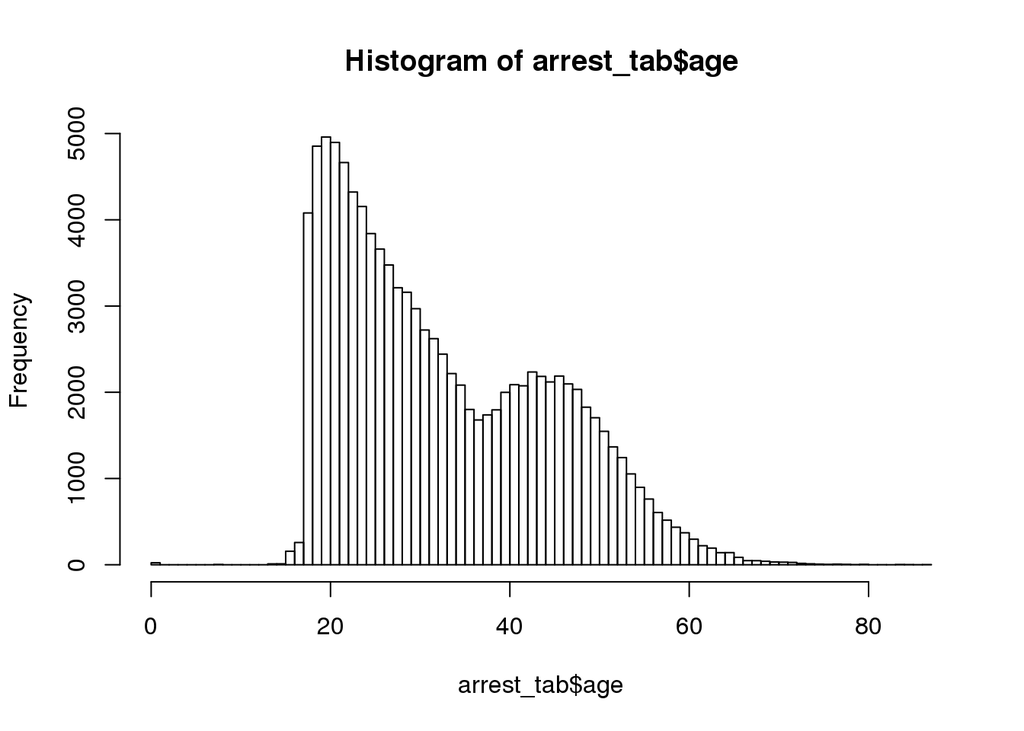

```r
hist(arrest_tab$age,nc=100)
```

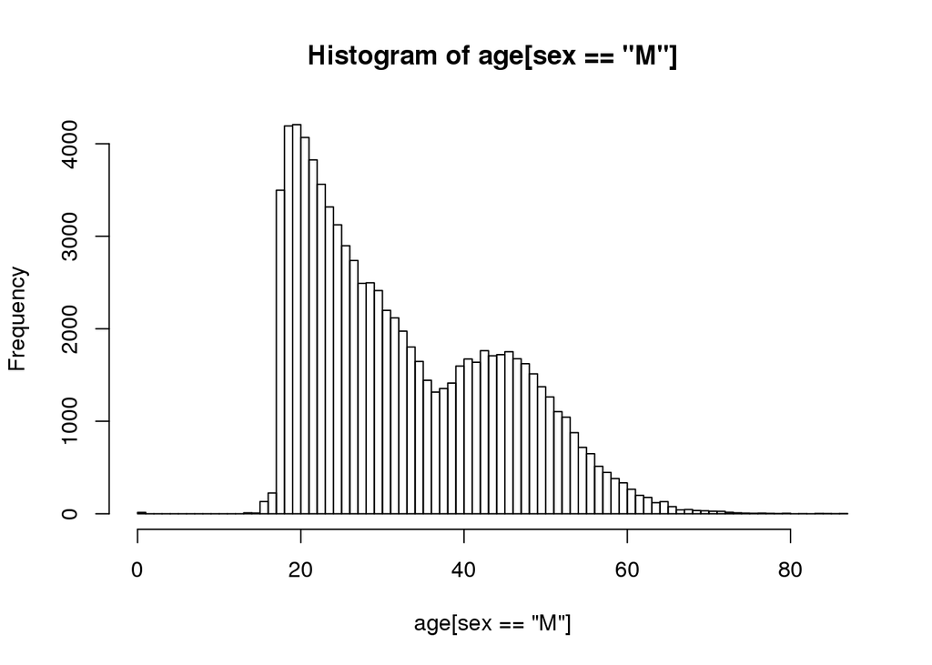

```r
with(arrest_tab,hist(age[sex=="M"],nc=100)) # males only
```

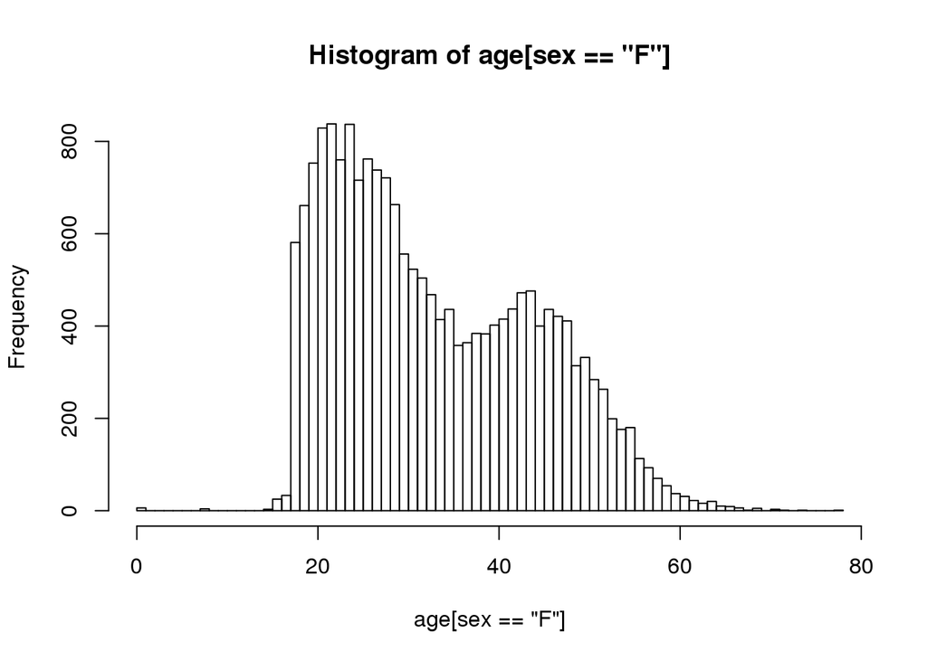

```r
with(arrest_tab,hist(age[sex=="F"],nc=100)) # females only
```

### Are males and females arrested at different ages on average?

Let’s take a look at how age depends on sex. Let’s plot age as a function of sex first (notice how we indicate that sex is a `factor`).

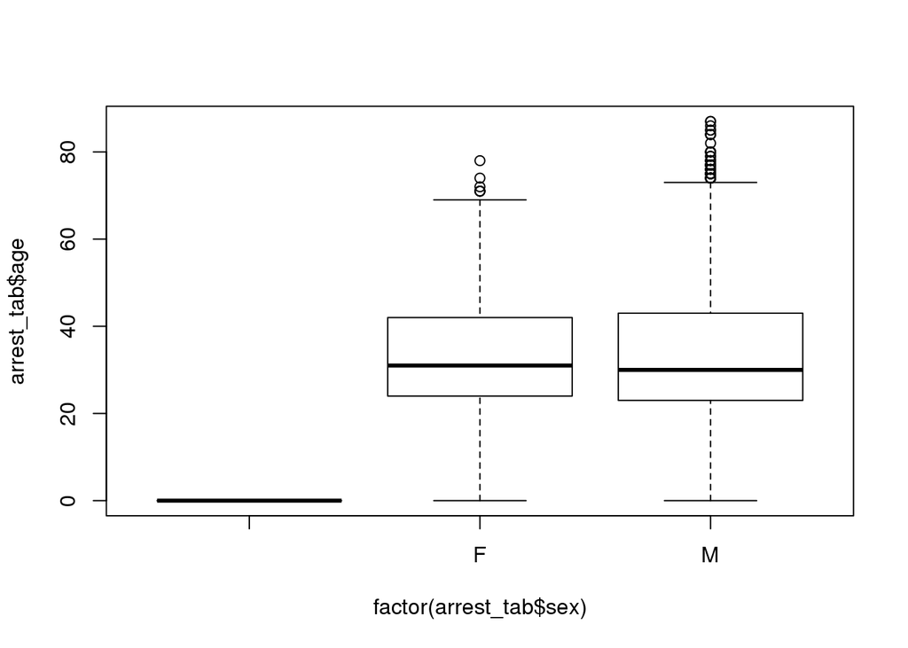

```r
plot(arrest_tab$age~factor(arrest_tab$sex))
```

One of the neat things about R is that statistical model building and testing is built-in. The model we use is $y_i=\beta_0+\beta_1 x_i$ where $y_i$ is age of sample (example) $i$ and $x_i$ is an indicator variable $x_i \in \{0,1\}$ with $x_i=1$ if the $i$-th record (example) is male. You can check that $\beta_1$ is the difference in mean age between females and males. We use the formula syntax to build a linear regression model.

```r
# let's ignore those records with missing sex
fit=lm(age~factor(sex),data=arrest_tab,subset=arrest_tab$sex %in% c("M","F"))
summary(fit)
```

```
##
## Call:
## lm(formula = age ~ factor(sex), data = arrest_tab, subset = arrest_tab$sex %in%
##     c("M", "F"))
##
## Residuals:
##     Min      1Q  Median      3Q     Max
## -33.388 -10.153  -3.153   9.612  53.847
##
## Coefficients:
##              Estimate Std. Error t value Pr(>|t|)
## (Intercept)  33.38778    0.08472 394.117   <2e-16 ***
## factor(sex)M -0.23432    0.09389  -2.496   0.0126 *
## ---
## Signif. codes:  0 '***' 0.001 '**' 0.01 '*' 0.05 '.' 0.1 ' ' 1
##
## Residual standard error: 11.81 on 104524 degrees of freedom
## Multiple R-squared:  5.958e-05,  Adjusted R-squared:  5.002e-05
## F-statistic: 6.228 on 1 and 104524 DF,  p-value: 0.01257
```

### Geographic distribution of arrests.

First we need to extract latitude and longitude from location, we’ll use some string functions to do this

```r
tmp=gsub("\\)","",gsub("\\(","",arrest_tab$Location))
tmp=strsplit(tmp,split=",")
arrest_tab$lon=as.numeric(sapply(tmp,function(x) x[2]))
arrest_tab$lat=as.numeric(sapply(tmp,function(x) x[1]))
```

Now let’s plot

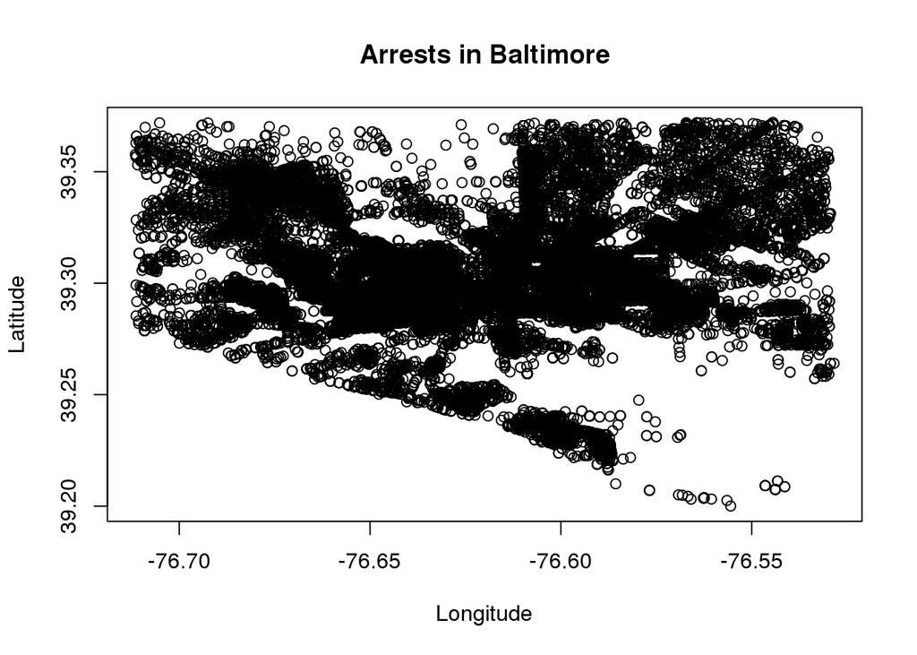

```r
plot(arrest_tab$lon, arrest_tab$lat, xlab="Longitude", ylab="Latitude", main="Arrests in Baltimore")
```

We can also use density estimates to make this nicer:

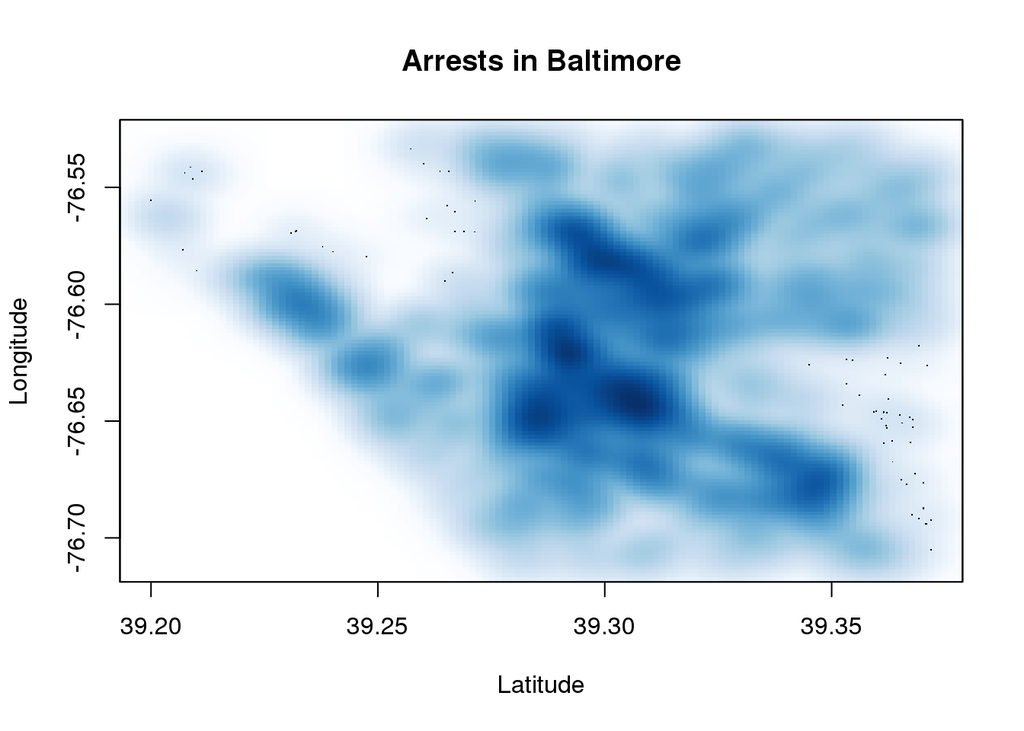

```r
smoothScatter(arrest_tab$lat, arrest_tab$lon, xlab="Latitude", ylab="Longitude", main="Arrests in Baltimore")
```

Let’s make this fancier using the `ggplot2` graphics systems and the `maps` package containing map data.

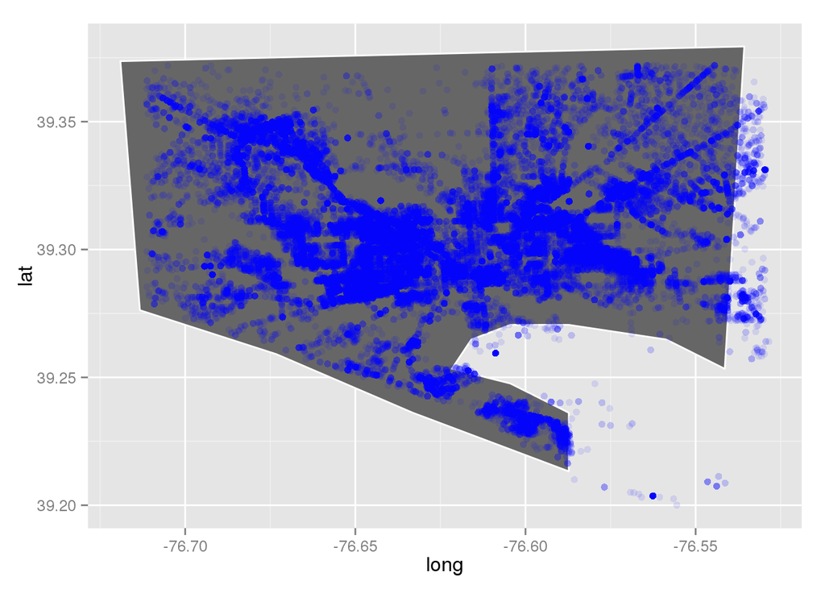

```r
library(maps)
library(ggplot2)

balto_map = subset(map_data("county", region="maryland"),subregion=="baltimore city")
plt=ggplot()
plt=plt+geom_polygon(data=balto_map,aes(x=long,y=lat),color="white",fill="gray40")
plt=plt+geom_point(data=arrest_tab,aes(x=lon,y=lat),color="blue",alpha=.1)
print(plt)
```

Now let’s add CCTV cameras.

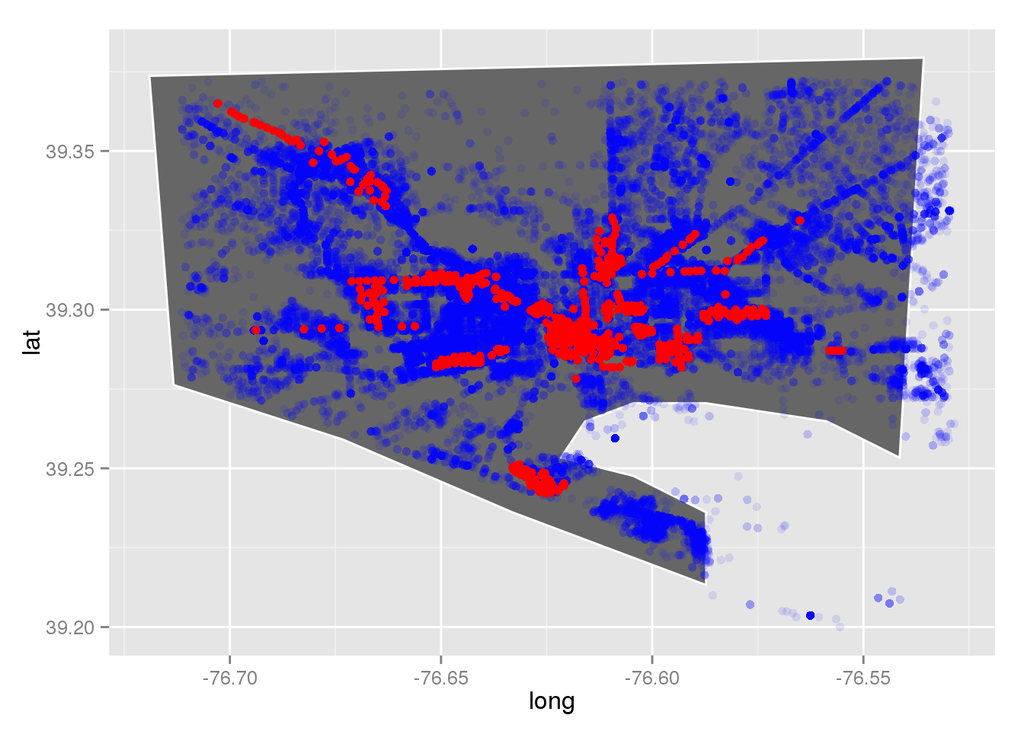

```r
tmp=gsub("\\)","",gsub("\\(","",cctv_tab$Location))
tmp=strsplit(tmp,split=",")
cctv_tab$lon=as.numeric(sapply(tmp,function(x) x[2]))
cctv_tab$lat=as.numeric(sapply(tmp,function(x) x[1]))

plt=ggplot()
plt=plt+geom_polygon(data=balto_map,aes(x=long,y=lat),color="white",fill="gray40")
plt=plt+geom_point(data=arrest_tab,aes(x=lon,y=lat),color="blue",alpha=.1)
plt=plt+geom_point(data=cctv_tab,aes(x=lon,y=lat),color="red")
print(plt)
```

### A challenge

Is there any relationship between the number of CCTV cameras and the number of arrests? Divide the city into a grid and plot the number of CCTV cameras vs. the number of arrests.

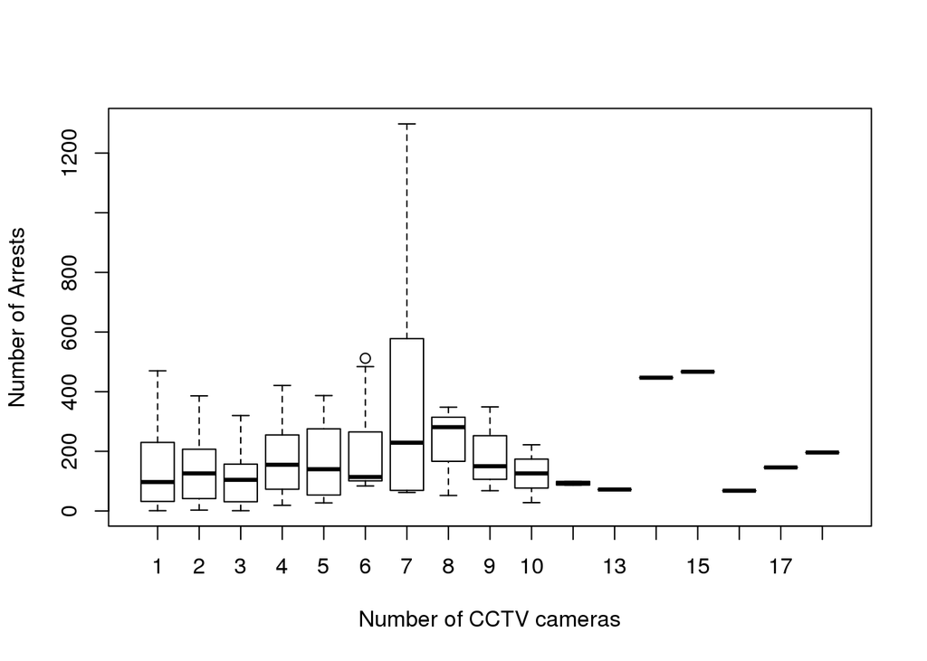

```r
# step 1: divide city intro grid for arrest data
# step 1a: find the range of latitude and longitude
latRange=range(arrest_tab$lat,na.rm=TRUE)
lonRange=range(arrest_tab$lon,na.rm=TRUE)

# step 1b: discretize latitude into 50 bins
latGrid=seq(min(latRange),max(latRange),len=50)
latFactor=cut(arrest_tab$lat,breaks=latGrid)

# now longitude
lonGrid=seq(min(lonRange),max(lonRange),len=50)
lonFactor=cut(arrest_tab$lon,breaks=lonGrid)

# step 1c: make a factor indicating geographic grid location
gridFactor=factor(paste(lonFactor,latFactor,sep=":"))

# step 2: do the same for the cctv data
latFactor=cut(cctv_tab$lat,breaks=latGrid)
lonFactor=cut(cctv_tab$lon,breaks=lonGrid)
cctvGridFactor=factor(paste(lonFactor,latFactor,sep=":"))

arrestTab=table(gridFactor)
cctvTab=table(cctvGridFactor)
m=match(names(cctvTab),names(arrestTab))
plot(arrestTab[m]~factor(cctvTab),xlab="Number of CCTV cameras", ylab="Number of Arrests")
```

### Extra analyses

As part of Project 1 you will add to this analysis. Please use the following template:

#### Mihai Sirbu

What question are you asking?:

I am trying to answer: at what time are most people arrested? For this prelimary analysis, I plan on making a plot where hour is the x-axis and the number of arrest is the y-axis. This will produced an “Arrest Timeseries.

What is the code you use to answer it?:

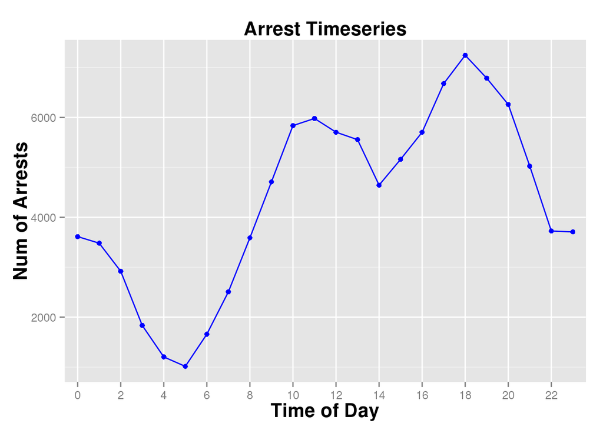

```r
time <- strptime(arrest_tab$arrestTime, "%H:%M")
arrest_tab$hours <- as.numeric(format(time, "%H"))

hours_df <- as.data.frame(table(arrest_tab$hours))
names(hours_df) <- c("hour","count")

g <- ggplot(hours_df, aes(hour, count, group=1))+geom_line(color="blue")+geom_point(color="blue")
g <- g+labs(title = "Arrest Timeseries", x="Time of Day",y="Num of Arrests")
g <- g+scale_x_discrete(breaks=seq(0,23,2))
g <- g + theme(plot.title=element_text(size=16,face="bold"),axis.title.x=element_text(size=16,face="bold"),axis.title.y=element_text(size=16,face="bold"))
g
```

What did you observe?

#### Aaron Dugatkin

What question are you asking?: I am trying to find out how cameras affect the sorts of crimes in their area, both in reducing certain types of crime, or leading to finding more of other types of crime.

What is the code you use to answer it?:

```r
# modified code from above, to create factors, but remove NA

# added by HCB to restore original arrest table
arrest_tab_original = arrest_tab
#

arrest_tab = arrest_tab[!is.na(arrest_tab$lat) & !is.na(arrest_tab$lon),]
latRange=range(arrest_tab$lat,na.rm=TRUE)
lonRange=range(arrest_tab$lon,na.rm=TRUE)
latGrid=seq(min(latRange),max(latRange),len=50)
latFactor=cut(arrest_tab$lat,breaks=latGrid)
lonGrid=seq(min(lonRange),max(lonRange),len=50)
lonFactor=cut(arrest_tab$lon,breaks=lonGrid)
gridFactor=factor(paste(lonFactor,latFactor,sep=":"))
latFactor=cut(cctv_tab$lat,breaks=latGrid)
lonFactor=cut(cctv_tab$lon,breaks=lonGrid)
cctvGridFactor=factor(paste(lonFactor,latFactor,sep=":"))
arrestTab=table(gridFactor)
cctvTab=table(cctvGridFactor)
#count crimes in areas with and without camera
arrestOnCamera = gridFactor %in% names(cctvTab)
count_crime_tab <- table(arrest_tab$incidentOffense, arrestOnCamera)
#merge the two tables, and calculate the difference in crime frequency in the two situations
crime_tab <- data.frame(count_crime_tab[,1], count_crime_tab[,2])
colnames(crime_tab)[1] <- "noCamCrimes"
colnames(crime_tab)[2] <- "camCrimes"
crime_tab$names <- rownames(crime_tab)
crime_tab$campct <- crime_tab$camCrimes/sum(crime_tab$camCrimes)*100
crime_tab$nocampct <- crime_tab$noCamCrimes/sum(crime_tab$noCamCrimes)*100
crime_tab$pctchange <- crime_tab$campct - crime_tab$nocampct
#display the change in crime frequency with crime name in descending order, with the most increased (caught) crimes first
crime_tab <- crime_tab[with(crime_tab, order(-pctchange)), ]
options(scipen=999)
subset(crime_tab, select=c("pctchange"))
```

```
##                                       pctchange
## 87-Narcotics                       8.7959299656
## 87O-Narcotics (Outside)            2.1085712279
## 55-Disorderly Person               0.4899152469
## 109-Loitering                      0.1601595042
## 79-Other                           0.1421819771
## 54-Armed Person                    0.0990559521
## 2A-Rape (Force)                    0.0638557474
## 6B-Larceny- Purse Snatch           0.0539250917
## 108-Liquor Law/Open Container      0.0514977916
## 117-Fto                            0.0498783769
## 1A-Murder                          0.0484986356
## 2B-Rape (Attempt)                  0.0480375073
## 3D-Robb Comm. (Ua)                 0.0476871064
## 61-Person Wanted On War            0.0430503173
## 7C-Stolen Veh./Other               0.0404124933
## 2F-Placing Hands                   0.0398369938
## 2D-Statutory Rape                  0.0392614943
## 3AO-Robb Hwy-Other Wpn             0.0381032079
## 88-Unfounded Call                  0.0316364803
## 78-Gambling                        0.0310500497
## 116-Public Urination / Defecation  0.0301387241
## 49-Family Disturbance              0.0279328789
## 5C-Burg. Res. (Noforce)            0.0253984949
## 58-Injured Person                  0.0226317250
## 3CK-Robb Comm-Knife                0.0165117545
## 60-Sick Person                     0.0163973833
## 8AO-Arson Sin Res Str-Occ          0.0148959835
## 80-Lost Property                   0.0130478265
## 20H-Traffic Control                0.0122399410
## 2H-Indecent Exp.                   0.0114284118
## 48-Involuntary Detention           0.0094658836
## 77-Dog Bite                        0.0087760130
## 73-False Pretense                  0.0083112410
## 106-Custody Dispute                0.0072746132
## 113-Littering                      0.0069278560
## 8J-Arson Other                     0.0061199705
## 76-Child Abuse-Sexual              0.0046185707
## 2C-Carnal Knowledge                0.0038106852
## 3M-Robb Bank (Ua)                  0.0038106852
```

[output cut: 71 more lines]

```
## 6G-Larceny- From Bldg.            -0.1242657852
## 7A-Stolen Auto                    -0.1317800717
## 115-Trespassing                   -0.1403564919
## 4A-Agg. Asslt.- Gun               -0.2195365579
## 75-Destruct. Of Property          -0.2844580826
## 4D-Agg. Asslt.- Hand              -0.3185182194
## 6C-Larceny- Shoplifting           -0.4077418953
## 4B-Agg. Asslt.- Cut               -0.4938461736
## 5A-Burg. Res. (Force)             -0.5879404416
## 4C-Agg. Asslt.- Oth.              -0.6379805575
## 24-Towed Vehicle                  -1.0684576178
## 97-Search & Seizure               -1.1822536848
## 55A-Prostitution                  -1.1994275774
## Unknown Offense                   -1.5811234143
## 4E-Common Assault                 -2.7616680093
```

```r
# added by HCB to restore original arrest table
arrest_tab = arrest_tab_original
```

What did you observe? The results were interesting. We see a large increase in charges of narcotics, which may be due to camera surveillance. We also see a decrease in assault, which may be due to the perpetrators of such crimes realizing the dangers of committing such crimes in front of a camera. However, the vast majority of crimes do not even see a 1% change between the two situations, so it would appear as though, overall, cameras do not have a major affect on criminal activity.

#### Anna Petrone

What question are you asking?: Which neighborhoods in Baltimore have the higest number of arrests?

What is the code you use to answer it?:

Load libraries

```r
library(rgdal) # needed for reading shape files
```

```r
library(plyr) # needed for rename function
library(sp) # needed for point.in.polygon function
library(ggmap) # could use for geocoding addresses
library(ggplot2) # needed for plotting
```

Find number of arrests for which the geo coordinates weren’t given

```r
no.geo.idx = nchar(arrest_tab$Location.1) == 0
n.geo.missing = sum( no.geo.idx )
narrests = dim(arrest_tab)[1]
n.geo.missing/narrests*100 # 39%
```

```
## [1] 38.87571
```

Find the number of incidents who dont have geo code info, but the incidentLocation is provided

```r
has.location = nchar(arrest_tab$incidentLocation) > 0
sum(no.geo.idx & has.location)
```

```
## [1] 7650
```

```r
#tmp = paste(arrest_tab$incidentLocation[no.geo.idx & has.location], "Baltimore, MD")
#gc = geocode(tmp[1:2490]) # restricted to 2500 api requests per day
```

Get the 2010 statistical community areas [here](http://bniajfi.org/mapping-resources/) Download the shape files and extract from the .zip file

```r
setwd("csa_2010_boundaries/")
csa = readOGR(dsn=".",layer="CSA_NSA_Tracts")
```

```
## with 56 features and 3 fields
## Feature type: wkbPolygon with 2 dimensions
```

```r
csa.df = fortify(csa) # fortify turns the shape data into a data.frame
csa.df = rename(csa.df, c("long"="X.feet","lat"="Y.feet")) # MD uses State Plane coords instead of lat/lon (see comments section)

convert = FALSE
if (convert){ # write a file to send to matlab code (described in comments section)
  write.csv(csa.df[,c("lat","lon")], "csa-df.txt",  quote=FALSE, na="",row.names=FALSE)
}
csa.converted.df = read.csv("csa-df_converted.txt",header=FALSE) # output of the matlab code, converted to lat/lon
setwd("..")

csa.converted.df = rename(csa.converted.df, c("V1"="lat","V2"="lon"))
csa.df = cbind(csa.df, csa.converted.df)
```

```r
ncsa = dim(csa)[1]
arrest_tab_geo = arrest_tab[!no.geo.idx,]
narrests.geo = dim(arrest_tab_geo)[1]

arrest_nbhd_id = vector(length = narrests.geo)

for (j in 1:ncsa) { # takes about 30 sec
  idx = csa.df$id == j-1
  polyx = csa.df$lon[idx]
  polyy = csa.df$lat[idx]

  in.poly = point.in.polygon(arrest_tab_geo$lon, arrest_tab_geo$lat, polyx,polyy)
  in.poly= as.logical(in.poly)
  arrest_nbhd_id[in.poly] = j - 1

}

arrest_tab_geo = cbind(arrest_tab_geo, arrest_nbhd_id)
```

For each neighborhood, count the number of arrests, using the table function

```r
nbhd.narrests = as.data.frame(table(arrest_nbhd_id))
nbhd.narrests = rename(nbhd.narrests, c("arrest_nbhd_id"="id", "Freq"="narrests"))
nbhd.names= as.vector(csa$Neigh)
nbhd.narrests = cbind(nbhd.names, nbhd.narrests)
head(nbhd.narrests)
```

```
##                                                                                                                nbhd.names
## 1 Allendale, Carroll-South Hilton, Gwynns Falls, Irvington, Saint Josephs, Uplands, Yale Heights, Lower Edmondson Village
## 2                                                     Beechfield, Hunting Ridge, Ten Hills, Tremont, West Hills, Westgate
## 3                                                   Belair-Edison, Clifton Park, Four By Four, Mayfield, Herring Run Park
## 4                                         Brooklyn, Curtis Bay, Fairfield Area, Hawkins Point, Curtis Bay Industrial Area
## 5                                                                                                  Canton, Patterson Park
## 6                                                                                   Cedonia, Frankford, Cedmont, Parkside
##   id narrests
## 1  0     1358
## 2  1      346
## 3  2     1752
## 4  3     2155
## 5  4      165
## 6  5     1330
```

Merge the arrest counts with the geometry data

```r
csa.df = merge(csa.df, nbhd.narrests, by="id",all.x=TRUE)
```

Make a plot colored by number of arrests

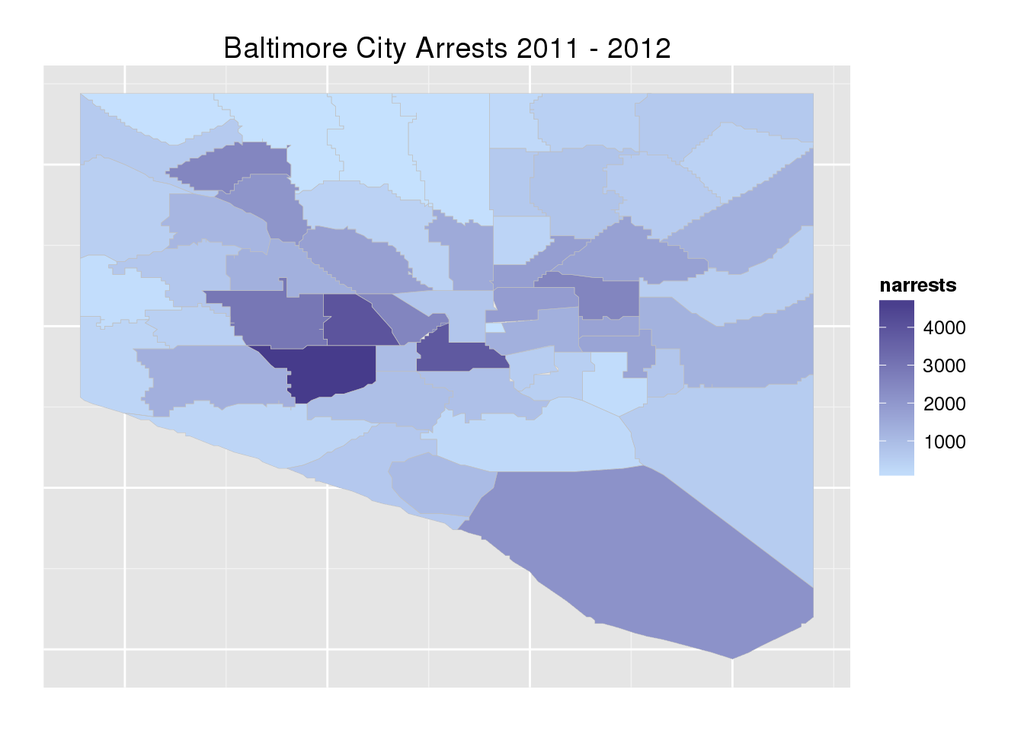

```r
g = ggplot(csa.df,aes(x=lon,y=lat,group=group))
g = g + geom_polygon(aes(fill=narrests)) + scale_fill_gradient(low="slategray1",high="slateblue4") # color the nbhds by narrests
g = g + geom_path(colour="gray75",size=.1) # draw lines separating the neighborhoods
g = g + ggtitle("Baltimore City Arrests 2011 - 2012") # add a title
g = g + theme(axis.ticks = element_blank(), axis.text.x = element_blank(), axis.text.y = element_blank(),
              axis.title.x = element_blank(), axis.title.y = element_blank()) # remove axis labels
print(g)
```

What did you observe? First, it should be noted that out of the 104,528 arrest records, 40,636 of them (about 39%) did not have geocoded locations (latitude and longitude). Some of them (7,650) did have and adress in the incidentLocation field, so it would be possible to geocode these, though it would not contribute enormously. (I did however take a look at the ggmap library which can convert an address string into lat and lon by calling the google maps geocoding API, however it only allows 2,500 requests per day.) Therefore my analysis only includes the 61% of records which provided geocoded information.

Second, I need to note that it was a pain converting from the [MD State Plane coordinates](http://en.wikipedia.org/wiki/State_Plane_Coordinate_System) into longitude and latitude. I ended up using [an external matlab function](http://www.mathworks.com/matlabcentral/fileexchange/26413-sp-proj) to do the conversion, since it seemed really confusing to do in R.

The results: As could probably be expected, the highest number of arrests occured in the downtown area, with the northwest area being notably high as well. The inner harbor neighborhood is among the lowest which makes sense as this area is more touristy. The neighborhoods in the central northern neighborhoods are also on the low end (I don’t know Baltiore but I’m guessing these are higher income neighborhoods).

For future analysis, it would be good to create a similar plot where the colors represent neighborhood income level. I would also like to add a layer showing the locations of transit stations, since these are commonly believed to attract crime.

#### Raul Alfaro

What question are you asking?: Which is the most common crime per race?

What is the code you use to answer it?:

```r
head(sort(table(arrest_tab$incidentOffense[arrest_tab$race=="A"]),decreasing=TRUE))
```

```
##
##         Unknown Offense            87-Narcotics       4E-Common Assault
##                      98                      42                      22
## 87O-Narcotics (Outside)        24-Towed Vehicle 61-Person Wanted On War
##                      13                      10                       6
```

```r
head(sort(table(arrest_tab$incidentOffense[arrest_tab$race=="B"]),decreasing=TRUE))
```

```
##
##         Unknown Offense            87-Narcotics 87O-Narcotics (Outside)
##                   31500                   21783                    5706
##       4E-Common Assault     97-Search & Seizure                79-Other
##                    5500                    3255                    2879
```

```r
head(sort(table(arrest_tab$incidentOffense[arrest_tab$race=="H"]),decreasing=TRUE))
```

```
## 87-Narcotics
##            1
```

```r
head(sort(table(arrest_tab$incidentOffense[arrest_tab$race=="I"]),decreasing=TRUE))
```

```
##
##      Unknown Offense         87-Narcotics    4E-Common Assault
##                   92                   44                   14
##  97-Search & Seizure     24-Towed Vehicle 4C-Agg. Asslt.- Oth.
##                    8                    6                    5
```

```r
head(sort(table(arrest_tab$incidentOffense[arrest_tab$race=="U"]),decreasing=TRUE))
```

```
##
##         Unknown Offense       4E-Common Assault            87-Narcotics
##                     893                     179                     171
## 87O-Narcotics (Outside)     4B-Agg. Asslt.- Cut                79-Other
##                      51                      48                      46
```

```r
head(sort(table(arrest_tab$incidentOffense[arrest_tab$race=="W"]),decreasing=TRUE))
```

```
##
##         Unknown Offense            87-Narcotics       4E-Common Assault
##                    6065                    2702                    1024
## 87O-Narcotics (Outside)        55A-Prostitution                79-Other
##                     740                     671                     528
```

What did you observe? I observed asside from the Unknown Offenses the most common crime for all races but 1 was Narcotics, the “race” had common Assault as their most common crime.

#### Kim St. Andrie, Rain Surasorn

What question are you asking?: Which year had the largest number of arrests?

What is the code you use to answer it?:

```r
a <- data.frame(id = arrest_tab$arrest, year = substr(arrest_tab$arrestDate,7,11))
head(sort(table(a$year), decreasing=TRUE),10)
```

```
##
##  2011  2012
## 52868 51660
```

What did you observe? 2011 had the largest number of arrests but there was no dramatic difference between the number of arrests for each year. There were 52,868 arrests in 2011 which was 1208 more than the number of arrests for 2012.

#### Rentao Wu

What are you asking:

I wanted to know if the ratio of female to male crime rates are similar accross the difference races.

What is the code you used to answer it?

```r
mytab = table(race=arrest_tab$race, sex=arrest_tab$sex)
#mydf$V1 = NULL
mydf = as.data.frame.matrix(mytab)
mydf$ratio = mydf$F/mydf$M
mydf$ratio <- round(mydf$ratio, 3)
mydf = mydf[-1,]
mydf
```

```
##   V1     F     M ratio
## A  0    37   205 0.180
## B  0 14663 72605 0.202
## H  0     0     1 0.000
## I  0    34   184 0.185
## U  0   183  1566 0.117
## W  0  4514 10534 0.429
```

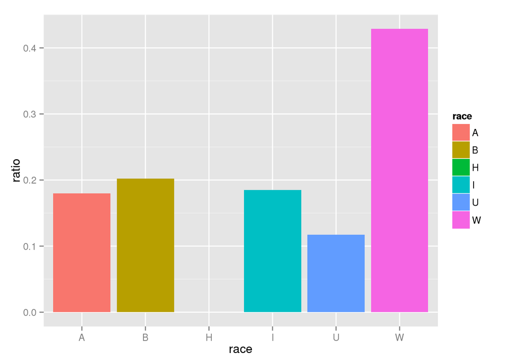

```r
mydf$race <- c("A","B","H","I","U","W")

ggplot(data=mydf, aes(x=race, y=ratio, fill=race)) + geom_bar(stat="identity")
```

What are your observations? I found out that for most race, the ratio of female to male crime rates is about 0.2. This tells us that there are about 1 female for ever 5 male criminal offenses. I also saw that the female to male crime ratio for the white population is about 0.43 which is much higher than the others.

#### Krishna Pai

What question are you asking?: Do police officers go out of their way to arrest more black people than white people?

What is the code you use to answer it?:

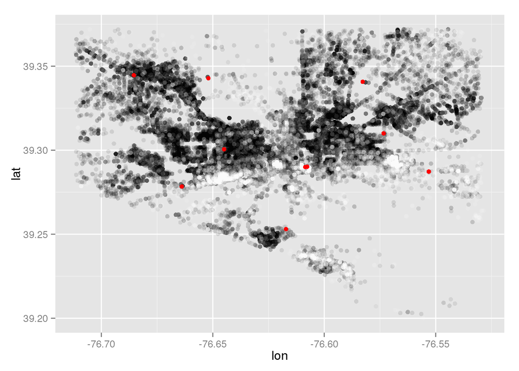

```r
library(ggplot2)
# added by HCB to not dirty global environment
kpai=function()
  {
    arrest_tab=read.csv("BPD_Arrests.csv", stringsAsFactors=FALSE)
    tmp=arrest_tab$sex
    arrest_tab$sex=arrest_tab$race
    arrest_tab$race=tmp
    police_tab=read.csv("Police_Stations.csv", stringsAsFactors=FALSE)
    tmp=gsub("\\)","",gsub("\\(","",arrest_tab$Location))
    tmp=strsplit(tmp,split=",")
    arrest_tab$lon=as.numeric(sapply(tmp,function(x) x[2]))
    arrest_tab$lat=as.numeric(sapply(tmp,function(x) x[1]))
    tmp=gsub("\\)","",gsub("\\(","",police_tab$Location))
    tmp=strsplit(tmp,split=",")
    police_tab$lon=as.numeric(sapply(tmp,function(x) x[2]))
    police_tab$lat=as.numeric(sapply(tmp,function(x) x[1]))
    plt=ggplot()
    plt=plt+geom_point(data=arrest_tab[arrest_tab$race=='B',],aes(x=lon,y=lat),color="black",alpha=.1)
    plt=plt+geom_point(data=arrest_tab[arrest_tab$race=='W',],aes(x=lon,y=lat),color="white",alpha=.1)
    plt=plt+geom_point(data=police_tab,aes(x=lon,y=lat),color="red")
    print(plt)
  }
kpai()
```

What did you observe? I was surprised to find that most of the arrests made some distance away from the cluster of police stations were for white people. It would be interesting to investigate what kinds of crimes might have been committed so far away from the stations, and why white people stand out as being arrested at that distance, especially in the east.

#### Ryan Wolniak, Brian Lindsey, and Kevin Wang

What question are you asking?: We are attempting to discern which season of the year has the highest number of prostitution offenses

What is the code you use to answer it?:

```r
arrest_tab=read.csv("BPD_Arrests.csv", stringsAsFactors=FALSE)
prostitution_arrests <- arrest_tab[which(arrest_tab$incidentOffense == '55A-Prostitution'),]

range(prostitution_arrests$arrestDate)
```

```
## [1] "01/02/2011" "12/30/2011"
```

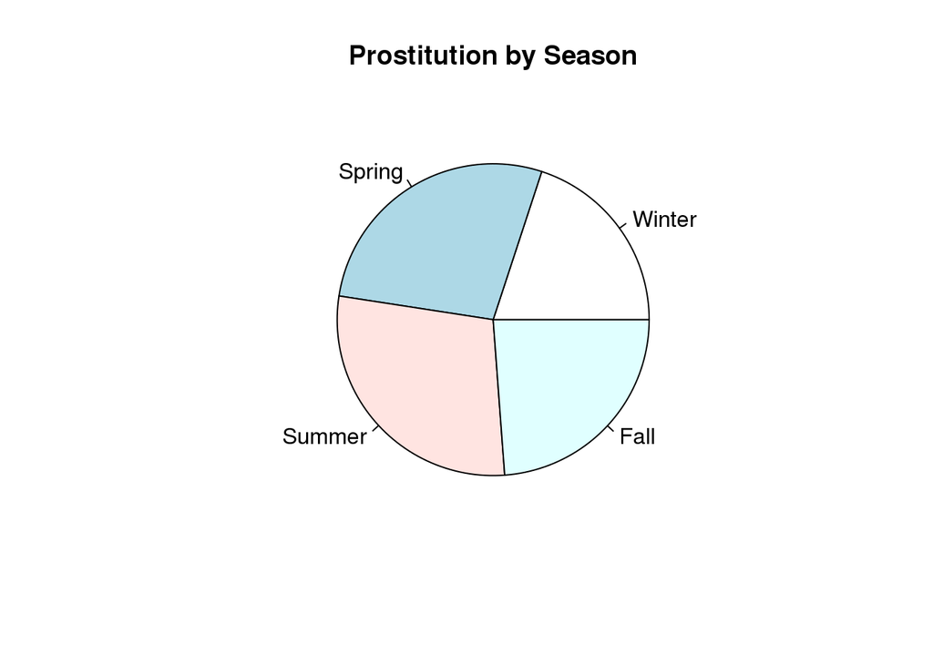

```r
dates <- as.Date(prostitution_arrests$arrestDate, "%m/%d/%Y")
winter_tab <- rbind(table(dates < "2011-03-20"),table(dates > "2011-12-22" & dates < "2012-03-20"), table(dates > "2012-12-22"))
winter_total <- sum(winter_tab[,"TRUE"])
spring_tab <- rbind(table(dates > "2011-03-19" & dates < "2011-06-21"),table(dates > "2012-03-19" & dates < "2012-06-20"))
spring_total <- sum(spring_tab[,"TRUE"])
summer_tab <- rbind(table(dates > "2011-06-20" & dates < "2011-09-22"),table(dates > "2012-06-19" & dates < "2012-09-22"))
summer_total <- sum(summer_tab[,"TRUE"])
fall_tab <- rbind(table(dates > "2011-09-21" & dates < "2011-12-23"),table(dates > "2012-09-21" & dates < "2012-12-22"))
fall_total <- sum(fall_tab[,"TRUE"])


slices <- c(winter_total, spring_total,summer_total,fall_total)
lbls <- c("Winter", "Spring", "Summer", "Fall")
pie(slices, labels = lbls, main = "Prostitution by Season")
```

What did you observe? We observed that the range function was exhibiting odd output when querying for the range of prostitutions. This led our search towards a new way of classifying the dates in order to clean the data and correct the output. After cleaning the data and running analysis, we found that there was a correlation between the warmer seasons and prostitution rate in Baltimore (where warmer months have a higher rate of prostitution).